# Results: Program 1

Levene Testi Sonuçları (Tüm Bağımlı Değişkenler)

The GLM Procedure

| Class Level Information Class | Class Level Information Levels | Class Level Information Values |
| --- | --- | --- |
| TRT_CLASS | 4 | 0 1 2 3 |
| STRAT_CLASS | 3 | 1 2 3 |

| Number of Observations Read | 2139 |
| --- | --- |
| Number of Observations Used | 2139 |

Levene Testi Sonuçları (Tüm Bağımlı Değişkenler)

The GLM Procedure

Dependent Variable: cd40

| Source | DF | Sum of Squares | Mean Square | F Value | Pr > F |
| --- | --- | --- | --- | --- | --- |
| Model | 11 | 525749.19 | 47795.38 | 3.44 | <.0001 |
| Error | 2127 | 29534019.56 | 13885.29 |  |  |
| Corrected Total | 2138 | 30059768.75 |  |  |  |

| R-Square | Coeff Var | Root MSE | cd40 Mean |
| --- | --- | --- | --- |
| 0.017490 | 33.61925 | 117.8359 | 350.5012 |

| Source | DF | Type I SS | Mean Square | F Value | Pr > F |
| --- | --- | --- | --- | --- | --- |
| TRT_CLASS*STRAT_CLAS | 11 | 525749.1904 | 47795.3809 | 3.44 | <.0001 |

| Source | DF | Type III SS | Mean Square | F Value | Pr > F |
| --- | --- | --- | --- | --- | --- |
| TRT_CLASS*STRAT_CLAS | 11 | 525749.1904 | 47795.3809 | 3.44 | <.0001 |

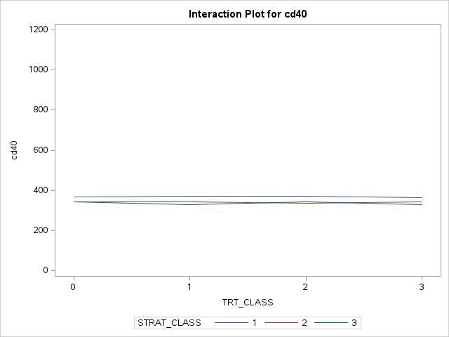

Levene Testi Sonuçları (Tüm Bağımlı Değişkenler)

The GLM Procedure

Dependent Variable: cd420

| Source | DF | Sum of Squares | Mean Square | F Value | Pr > F |
| --- | --- | --- | --- | --- | --- |
| Model | 11 | 3401946.86 | 309267.90 | 15.92 | <.0001 |
| Error | 2127 | 41323424.34 | 19428.03 |  |  |
| Corrected Total | 2138 | 44725371.20 |  |  |  |

| R-Square | Coeff Var | Root MSE | cd420 Mean |
| --- | --- | --- | --- |
| 0.076063 | 37.53886 | 139.3845 | 371.3072 |

| Source | DF | Type I SS | Mean Square | F Value | Pr > F |
| --- | --- | --- | --- | --- | --- |
| TRT_CLASS*STRAT_CLAS | 11 | 3401946.858 | 309267.896 | 15.92 | <.0001 |

| Source | DF | Type III SS | Mean Square | F Value | Pr > F |
| --- | --- | --- | --- | --- | --- |
| TRT_CLASS*STRAT_CLAS | 11 | 3401946.858 | 309267.896 | 15.92 | <.0001 |

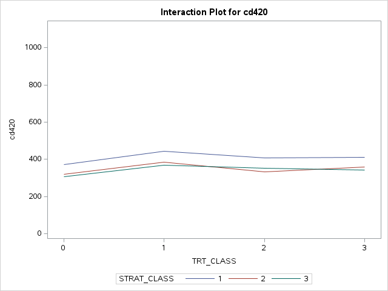

Levene Testi Sonuçları (Tüm Bağımlı Değişkenler)

The GLM Procedure

Dependent Variable: cd80

| Source | DF | Sum of Squares | Mean Square | F Value | Pr > F |
| --- | --- | --- | --- | --- | --- |
| Model | 11 | 2855799.1 | 259618.1 | 1.13 | 0.3356 |
| Error | 2127 | 490145362.9 | 230439.8 |  |  |
| Corrected Total | 2138 | 493001162.0 |  |  |  |

| R-Square | Coeff Var | Root MSE | cd80 Mean |
| --- | --- | --- | --- |
| 0.005793 | 48.65478 | 480.0414 | 986.6274 |

| Source | DF | Type I SS | Mean Square | F Value | Pr > F |
| --- | --- | --- | --- | --- | --- |
| TRT_CLASS*STRAT_CLAS | 11 | 2855799.118 | 259618.102 | 1.13 | 0.3356 |

| Source | DF | Type III SS | Mean Square | F Value | Pr > F |
| --- | --- | --- | --- | --- | --- |
| TRT_CLASS*STRAT_CLAS | 11 | 2855799.118 | 259618.102 | 1.13 | 0.3356 |

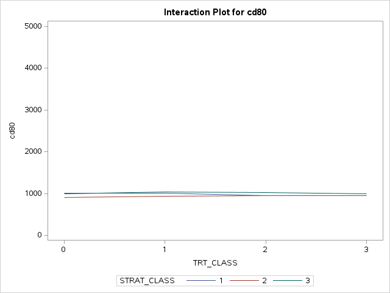

Levene Testi Sonuçları (Tüm Bağımlı Değişkenler)

The GLM Procedure

Dependent Variable: cd820

| Source | DF | Sum of Squares | Mean Square | F Value | Pr > F |
| --- | --- | --- | --- | --- | --- |
| Model | 11 | 2464079.6 | 224007.2 | 1.13 | 0.3313 |
| Error | 2127 | 420867800.9 | 197869.2 |  |  |
| Corrected Total | 2138 | 423331880.5 |  |  |  |

| R-Square | Coeff Var | Root MSE | cd820 Mean |
| --- | --- | --- | --- |
| 0.005821 | 47.55605 | 444.8249 | 935.3698 |

| Source | DF | Type I SS | Mean Square | F Value | Pr > F |
| --- | --- | --- | --- | --- | --- |
| TRT_CLASS*STRAT_CLAS | 11 | 2464079.617 | 224007.238 | 1.13 | 0.3313 |

| Source | DF | Type III SS | Mean Square | F Value | Pr > F |
| --- | --- | --- | --- | --- | --- |
| TRT_CLASS*STRAT_CLAS | 11 | 2464079.617 | 224007.238 | 1.13 | 0.3313 |

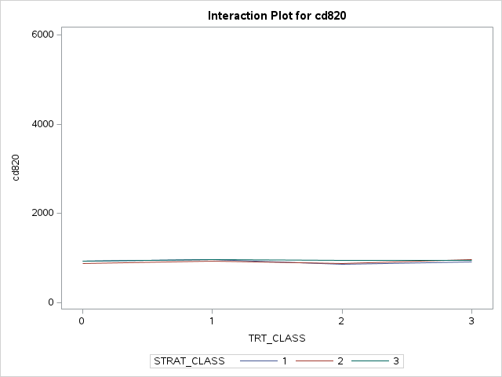

Levene Testi Sonuçları (Tüm Bağımlı Değişkenler)

The GLM Procedure

| Levene's Test for Homogeneity of cd40 Variance ANOVA of Squared Deviations from Group Means Source | Levene's Test for Homogeneity of cd40 Variance ANOVA of Squared Deviations from Group Means DF | Levene's Test for Homogeneity of cd40 Variance ANOVA of Squared Deviations from Group Means Sum of Squares | Levene's Test for Homogeneity of cd40 Variance ANOVA of Squared Deviations from Group Means Mean Square | Levene's Test for Homogeneity of cd40 Variance ANOVA of Squared Deviations from Group Means F Value | Levene's Test for Homogeneity of cd40 Variance ANOVA of Squared Deviations from Group Means Pr > F |
| --- | --- | --- | --- | --- | --- |
| TRT_CLASS*STRAT_CLAS | 11 | 9.7561E9 | 8.8691E8 | 1.23 | 0.2587 |
| Error | 2127 | 1.529E12 | 7.1904E8 |  |  |

| Levene's Test for Homogeneity of cd420 Variance ANOVA of Squared Deviations from Group Means Source | Levene's Test for Homogeneity of cd420 Variance ANOVA of Squared Deviations from Group Means DF | Levene's Test for Homogeneity of cd420 Variance ANOVA of Squared Deviations from Group Means Sum of Squares | Levene's Test for Homogeneity of cd420 Variance ANOVA of Squared Deviations from Group Means Mean Square | Levene's Test for Homogeneity of cd420 Variance ANOVA of Squared Deviations from Group Means F Value | Levene's Test for Homogeneity of cd420 Variance ANOVA of Squared Deviations from Group Means Pr > F |
| --- | --- | --- | --- | --- | --- |
| TRT_CLASS*STRAT_CLAS | 11 | 2.181E10 | 1.9824E9 | 1.64 | 0.0806 |
| Error | 2127 | 2.565E12 | 1.2059E9 |  |  |

| Levene's Test for Homogeneity of cd80 Variance ANOVA of Squared Deviations from Group Means Source | Levene's Test for Homogeneity of cd80 Variance ANOVA of Squared Deviations from Group Means DF | Levene's Test for Homogeneity of cd80 Variance ANOVA of Squared Deviations from Group Means Sum of Squares | Levene's Test for Homogeneity of cd80 Variance ANOVA of Squared Deviations from Group Means Mean Square | Levene's Test for Homogeneity of cd80 Variance ANOVA of Squared Deviations from Group Means F Value | Levene's Test for Homogeneity of cd80 Variance ANOVA of Squared Deviations from Group Means Pr > F |
| --- | --- | --- | --- | --- | --- |
| TRT_CLASS*STRAT_CLAS | 11 | 3.674E12 | 3.34E11 | 0.77 | 0.6741 |
| Error | 2127 | 9.269E14 | 4.358E11 |  |  |

| Levene's Test for Homogeneity of cd820 Variance ANOVA of Squared Deviations from Group Means Source | Levene's Test for Homogeneity of cd820 Variance ANOVA of Squared Deviations from Group Means DF | Levene's Test for Homogeneity of cd820 Variance ANOVA of Squared Deviations from Group Means Sum of Squares | Levene's Test for Homogeneity of cd820 Variance ANOVA of Squared Deviations from Group Means Mean Square | Levene's Test for Homogeneity of cd820 Variance ANOVA of Squared Deviations from Group Means F Value | Levene's Test for Homogeneity of cd820 Variance ANOVA of Squared Deviations from Group Means Pr > F |
| --- | --- | --- | --- | --- | --- |
| TRT_CLASS*STRAT_CLAS | 11 | 6.164E12 | 5.604E11 | 1.06 | 0.3880 |
| Error | 2127 | 1.122E15 | 5.273E11 |  |  |

Levene Testi Sonuçları (Tüm Bağımlı Değişkenler)

The GLM Procedure

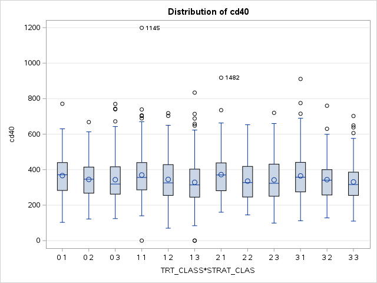

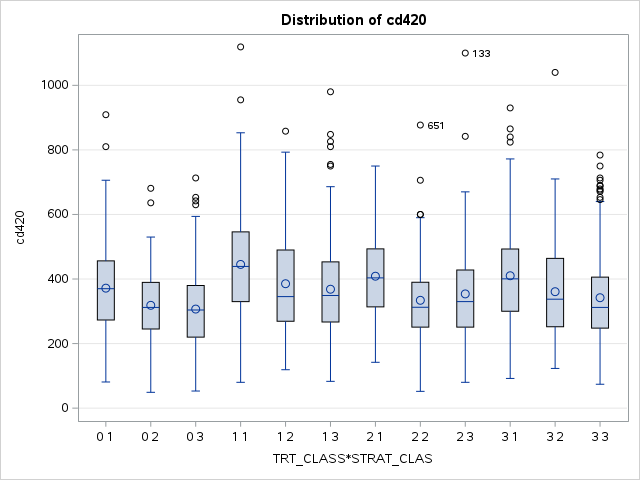

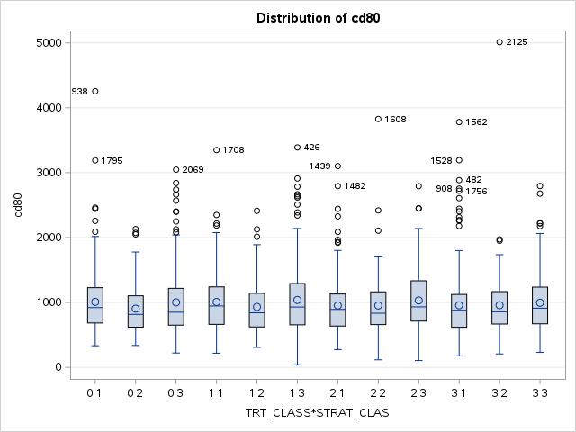

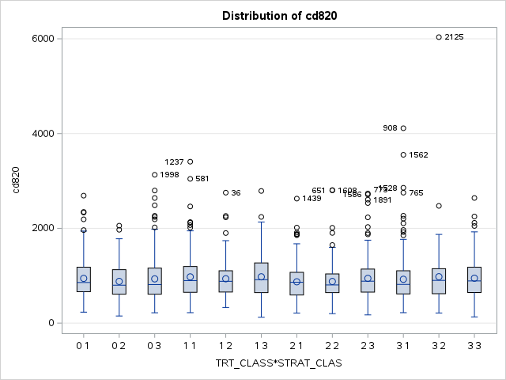

| Level of TRT_CLASS | Level of STRAT_CLASS | N | cd40 Mean | cd40 Std Dev | cd420 Mean | cd420 Std Dev | cd80 Mean | cd80 Std Dev | cd820 Mean | cd820 Std Dev |
| --- | --- | --- | --- | --- | --- | --- | --- | --- | --- | --- |
| 0 | 1 | 223 | 366.336323 | 109.823154 | 371.672646 | 136.252665 | 1008.87892 | 479.182984 | 943.784753 | 420.089210 |
| 0 | 2 | 96 | 344.802083 | 109.475748 | 318.500000 | 116.903289 | 904.44792 | 378.027926 | 879.927083 | 401.977382 |
| 0 | 3 | 213 | 343.244131 | 119.573166 | 306.887324 | 122.739241 | 1001.92488 | 507.308170 | 933.676056 | 472.458617 |
| 1 | 1 | 213 | 369.798122 | 136.132641 | 445.159624 | 154.239592 | 1007.95775 | 465.122050 | 975.314554 | 463.131374 |
| 1 | 2 | 106 | 344.896226 | 126.066190 | 385.415094 | 156.966291 | 932.03774 | 416.544331 | 936.075472 | 411.348021 |
| 1 | 3 | 203 | 328.610837 | 123.001454 | 368.389163 | 148.315897 | 1038.23645 | 541.281211 | 976.931034 | 429.849462 |
| 2 | 1 | 212 | 371.943396 | 117.539170 | 408.702830 | 124.880232 | 953.64151 | 435.013508 | 871.948113 | 359.019758 |
| 2 | 2 | 106 | 335.273585 | 110.972028 | 334.047170 | 129.756577 | 953.25472 | 484.245590 | 878.443396 | 424.937106 |
| 2 | 3 | 206 | 342.053398 | 113.382590 | 353.854369 | 139.186690 | 1031.33010 | 452.256702 | 944.063107 | 432.312693 |
| 3 | 1 | 238 | 364.668067 | 122.483836 | 410.126050 | 146.410270 | 955.71849 | 521.310869 | 924.487395 | 487.001882 |
| 3 | 2 | 102 | 343.519608 | 114.391696 | 360.735294 | 152.860185 | 957.52941 | 555.378414 | 978.519608 | 631.951351 |
| 3 | 3 | 221 | 330.764706 | 102.522808 | 342.040724 | 137.605937 | 996.04525 | 455.903915 | 947.425339 | 412.530572 |

Çok Yönlü MANOVA Sonuçları

The GLM Procedure

| Class Level Information Class | Class Level Information Levels | Class Level Information Values |
| --- | --- | --- |
| TRT_CLASS | 4 | 0 1 2 3 |
| STRAT_CLASS | 3 | 1 2 3 |

| Number of Observations Read | 2139 |
| --- | --- |
| Number of Observations Used | 2139 |

Çok Yönlü MANOVA Sonuçları

The GLM Procedure

Dependent Variable: cd40

| Source | DF | Sum of Squares | Mean Square | F Value | Pr > F |
| --- | --- | --- | --- | --- | --- |
| Model | 11 | 525749.19 | 47795.38 | 3.44 | <.0001 |
| Error | 2127 | 29534019.56 | 13885.29 |  |  |
| Corrected Total | 2138 | 30059768.75 |  |  |  |

| R-Square | Coeff Var | Root MSE | cd40 Mean |
| --- | --- | --- | --- |
| 0.017490 | 33.61925 | 117.8359 | 350.5012 |

| Source | DF | Type I SS | Mean Square | F Value | Pr > F |
| --- | --- | --- | --- | --- | --- |
| TRT_CLASS | 3 | 13410.7365 | 4470.2455 | 0.32 | 0.8095 |
| STRAT_CLASS | 2 | 477041.2577 | 238520.6289 | 17.18 | <.0001 |
| TRT_CLASS*STRAT_CLAS | 6 | 35297.1962 | 5882.8660 | 0.42 | 0.8636 |

| Source | DF | Type III SS | Mean Square | F Value | Pr > F |
| --- | --- | --- | --- | --- | --- |
| TRT_CLASS | 3 | 7181.0397 | 2393.6799 | 0.17 | 0.9151 |
| STRAT_CLASS | 2 | 478233.4182 | 239116.7091 | 17.22 | <.0001 |
| TRT_CLASS*STRAT_CLAS | 6 | 35297.1962 | 5882.8660 | 0.42 | 0.8636 |

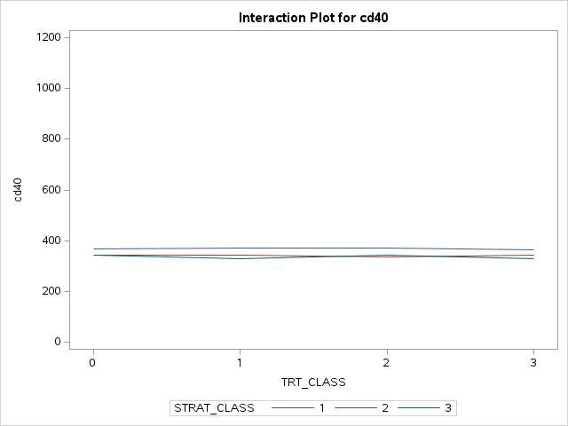

Çok Yönlü MANOVA Sonuçları

The GLM Procedure

Dependent Variable: cd420

| Source | DF | Sum of Squares | Mean Square | F Value | Pr > F |
| --- | --- | --- | --- | --- | --- |
| Model | 11 | 3401946.86 | 309267.90 | 15.92 | <.0001 |
| Error | 2127 | 41323424.34 | 19428.03 |  |  |
| Corrected Total | 2138 | 44725371.20 |  |  |  |

| R-Square | Coeff Var | Root MSE | cd420 Mean |
| --- | --- | --- | --- |
| 0.076063 | 37.53886 | 139.3845 | 371.3072 |

| Source | DF | Type I SS | Mean Square | F Value | Pr > F |
| --- | --- | --- | --- | --- | --- |
| TRT_CLASS | 3 | 1193396.819 | 397798.940 | 20.48 | <.0001 |
| STRAT_CLASS | 2 | 2131778.294 | 1065889.147 | 54.86 | <.0001 |
| TRT_CLASS*STRAT_CLAS | 6 | 76771.745 | 12795.291 | 0.66 | 0.6832 |

| Source | DF | Type III SS | Mean Square | F Value | Pr > F |
| --- | --- | --- | --- | --- | --- |
| TRT_CLASS | 3 | 1063332.827 | 354444.276 | 18.24 | <.0001 |
| STRAT_CLASS | 2 | 2126589.792 | 1063294.896 | 54.73 | <.0001 |
| TRT_CLASS*STRAT_CLAS | 6 | 76771.745 | 12795.291 | 0.66 | 0.6832 |

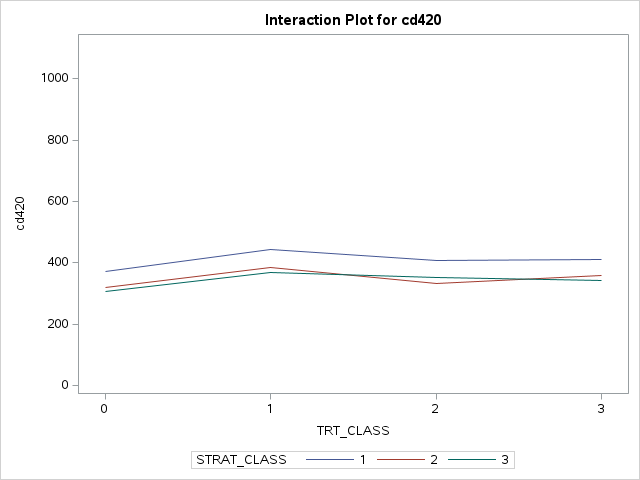

Çok Yönlü MANOVA Sonuçları

The GLM Procedure

Dependent Variable: cd80

| Source | DF | Sum of Squares | Mean Square | F Value | Pr > F |
| --- | --- | --- | --- | --- | --- |
| Model | 11 | 2855799.1 | 259618.1 | 1.13 | 0.3356 |
| Error | 2127 | 490145362.9 | 230439.8 |  |  |
| Corrected Total | 2138 | 493001162.0 |  |  |  |

| R-Square | Coeff Var | Root MSE | cd80 Mean |
| --- | --- | --- | --- |
| 0.005793 | 48.65478 | 480.0414 | 986.6274 |

| Source | DF | Type I SS | Mean Square | F Value | Pr > F |
| --- | --- | --- | --- | --- | --- |
| TRT_CLASS | 3 | 287985.653 | 95995.218 | 0.42 | 0.7411 |
| STRAT_CLASS | 2 | 1781404.683 | 890702.342 | 3.87 | 0.0211 |
| TRT_CLASS*STRAT_CLAS | 6 | 786408.782 | 131068.130 | 0.57 | 0.7555 |

| Source | DF | Type III SS | Mean Square | F Value | Pr > F |
| --- | --- | --- | --- | --- | --- |
| TRT_CLASS | 3 | 154188.034 | 51396.011 | 0.22 | 0.8804 |
| STRAT_CLASS | 2 | 1809100.146 | 904550.073 | 3.93 | 0.0199 |
| TRT_CLASS*STRAT_CLAS | 6 | 786408.782 | 131068.130 | 0.57 | 0.7555 |

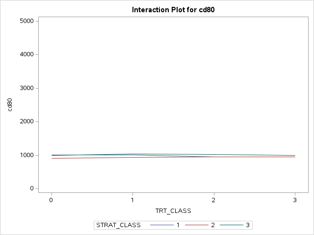

Çok Yönlü MANOVA Sonuçları

The GLM Procedure

Dependent Variable: cd820

| Source | DF | Sum of Squares | Mean Square | F Value | Pr > F |
| --- | --- | --- | --- | --- | --- |
| Model | 11 | 2464079.6 | 224007.2 | 1.13 | 0.3313 |
| Error | 2127 | 420867800.9 | 197869.2 |  |  |
| Corrected Total | 2138 | 423331880.5 |  |  |  |

| R-Square | Coeff Var | Root MSE | cd820 Mean |
| --- | --- | --- | --- |
| 0.005821 | 47.55605 | 444.8249 | 935.3698 |

| Source | DF | Type I SS | Mean Square | F Value | Pr > F |
| --- | --- | --- | --- | --- | --- |
| TRT_CLASS | 3 | 1215008.665 | 405002.888 | 2.05 | 0.1053 |
| STRAT_CLASS | 2 | 342064.785 | 171032.393 | 0.86 | 0.4215 |
| TRT_CLASS*STRAT_CLAS | 6 | 907006.167 | 151167.695 | 0.76 | 0.5983 |

| Source | DF | Type III SS | Mean Square | F Value | Pr > F |
| --- | --- | --- | --- | --- | --- |
| TRT_CLASS | 3 | 1224780.135 | 408260.045 | 2.06 | 0.1031 |
| STRAT_CLASS | 2 | 350666.630 | 175333.315 | 0.89 | 0.4124 |
| TRT_CLASS*STRAT_CLAS | 6 | 907006.167 | 151167.695 | 0.76 | 0.5983 |

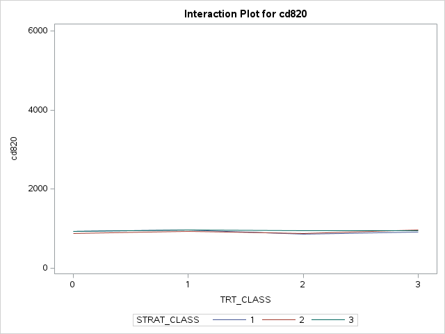

Çok Yönlü MANOVA Sonuçları

The GLM Procedure

Multivariate Analysis of Variance

| E = Error SSCP Matrix | E = Error SSCP Matrix cd40 | E = Error SSCP Matrix cd420 | E = Error SSCP Matrix cd80 | E = Error SSCP Matrix cd820 |
| --- | --- | --- | --- | --- |
| cd40 | 29534019.557 | 20433319.857 | 26392544.51 | 8529068.4182 |
| cd420 | 20433319.857 | 41323424.342 | 8216695.3317 | 29411019.432 |
| cd80 | 26392544.51 | 8216695.3317 | 490145362.92 | 343682591.12 |
| cd820 | 8529068.4182 | 29411019.432 | 343682591.12 | 420867800.87 |

| Partial Correlation Coefficients from the Error SSCP Matrix / Prob > \|r\| DF = 2127 | Partial Correlation Coefficients from the Error SSCP Matrix / Prob > \|r\| cd40 | Partial Correlation Coefficients from the Error SSCP Matrix / Prob > \|r\| cd420 | Partial Correlation Coefficients from the Error SSCP Matrix / Prob > \|r\| cd80 | Partial Correlation Coefficients from the Error SSCP Matrix / Prob > \|r\| cd820 |
| --- | --- | --- | --- | --- |
| cd40 | 1.000000 | 0.584897 <.0001 | 0.219360 <.0001 | 0.076501 0.0004 |
| cd420 | 0.584897 <.0001 | 1.000000 | 0.057735 0.0077 | 0.223018 <.0001 |
| cd80 | 0.219360 <.0001 | 0.057735 0.0077 | 1.000000 | 0.756697 <.0001 |
| cd820 | 0.076501 0.0004 | 0.223018 <.0001 | 0.756697 <.0001 | 1.000000 |

Çok Yönlü MANOVA Sonuçları

The GLM Procedure

Multivariate Analysis of Variance

| H = Type III SSCP Matrix for TRT_CLASS | H = Type III SSCP Matrix for TRT_CLASS cd40 | H = Type III SSCP Matrix for TRT_CLASS cd420 | H = Type III SSCP Matrix for TRT_CLASS cd80 | H = Type III SSCP Matrix for TRT_CLASS cd820 |
| --- | --- | --- | --- | --- |
| cd40 | 7181.0397047 | -63692.26455 | -4245.803193 | -67923.56029 |
| cd420 | -63692.26455 | 1063332.8273 | 309701.08274 | 737335.46423 |
| cd80 | -4245.803193 | 309701.08274 | 154188.03392 | 155523.43242 |
| cd820 | -67923.56029 | 737335.46423 | 155523.43242 | 1224780.1345 |

| Characteristic Roots and Vectors of: E Inverse * H, where H = Type III SSCP Matrix for TRT_CLASS E = Error SSCP Matrix Characteristic Root | Characteristic Roots and Vectors of: E Inverse * H, where H = Type III SSCP Matrix for TRT_CLASS E = Error SSCP Matrix Percent | Characteristic Roots and Vectors of: E Inverse * H, where H = Type III SSCP Matrix for TRT_CLASS E = Error SSCP Matrix Characteristic Vector V'EV=1 cd40 | Characteristic Roots and Vectors of: E Inverse * H, where H = Type III SSCP Matrix for TRT_CLASS E = Error SSCP Matrix Characteristic Vector V'EV=1 cd420 | Characteristic Roots and Vectors of: E Inverse * H, where H = Type III SSCP Matrix for TRT_CLASS E = Error SSCP Matrix Characteristic Vector V'EV=1 cd80 | Characteristic Roots and Vectors of: E Inverse * H, where H = Type III SSCP Matrix for TRT_CLASS E = Error SSCP Matrix Characteristic Vector V'EV=1 cd820 |
| --- | --- | --- | --- | --- | --- |
| 0.04817146 | 90.11 | -0.00017269 | 0.00021222 | 0.00002731 | -0.00002674 |
| 0.00514102 | 9.62 | 0.00003088 | -0.00002989 | -0.00005922 | 0.00007930 |
| 0.00014705 | 0.28 | 0.00009861 | -0.00000778 | 0.00002850 | 0.00000820 |
| 0.00000000 | 0.00 | 0.00015308 | 0.00001678 | -0.00003196 | 0.00000244 |

| MANOVA Test Criteria and F Approximations for the Hypothesis of No Overall TRT_CLASS Effect H = Type III SSCP Matrix for TRT_CLASS E = Error SSCP Matrix S=3 M=0 N=1061 Statistic | MANOVA Test Criteria and F Approximations for the Hypothesis of No Overall TRT_CLASS Effect H = Type III SSCP Matrix for TRT_CLASS E = Error SSCP Matrix S=3 M=0 N=1061 Value | MANOVA Test Criteria and F Approximations for the Hypothesis of No Overall TRT_CLASS Effect H = Type III SSCP Matrix for TRT_CLASS E = Error SSCP Matrix S=3 M=0 N=1061 F Value | MANOVA Test Criteria and F Approximations for the Hypothesis of No Overall TRT_CLASS Effect H = Type III SSCP Matrix for TRT_CLASS E = Error SSCP Matrix S=3 M=0 N=1061 Num DF | MANOVA Test Criteria and F Approximations for the Hypothesis of No Overall TRT_CLASS Effect H = Type III SSCP Matrix for TRT_CLASS E = Error SSCP Matrix S=3 M=0 N=1061 Den DF | MANOVA Test Criteria and F Approximations for the Hypothesis of No Overall TRT_CLASS Effect H = Type III SSCP Matrix for TRT_CLASS E = Error SSCP Matrix S=3 M=0 N=1061 Pr > F |
| --- | --- | --- | --- | --- | --- |
| Wilks' Lambda | 0.94902317 | 9.35 | 12 | 5619.9 | <.0001 |
| Pillai's Trace | 0.05121937 | 9.23 | 12 | 6378 | <.0001 |
| Hotelling-Lawley Trace | 0.05345953 | 9.46 | 12 | 3712.7 | <.0001 |
| Roy's Greatest Root | 0.04817146 | 25.60 | 4 | 2126 | <.0001 |

NOTE: F Statistic for Roy's Greatest Root is an upper bound.

| H = Type III SSCP Matrix for STRAT_CLASS | H = Type III SSCP Matrix for STRAT_CLASS cd40 | H = Type III SSCP Matrix for STRAT_CLASS cd420 | H = Type III SSCP Matrix for STRAT_CLASS cd80 | H = Type III SSCP Matrix for STRAT_CLASS cd820 |
| --- | --- | --- | --- | --- |
| cd40 | 478233.41818 | 1006337.748 | -273806.2793 | -225576.9205 |
| cd420 | 1006337.748 | 2126589.7924 | -454409.4932 | -427863.7964 |
| cd80 | -273806.2793 | -454409.4932 | 1809100.1459 | 764452.12942 |
| cd820 | -225576.9205 | -427863.7964 | 764452.12942 | 350666.62962 |

| Characteristic Roots and Vectors of: E Inverse * H, where H = Type III SSCP Matrix for STRAT_CLASS E = Error SSCP Matrix Characteristic Root | Characteristic Roots and Vectors of: E Inverse * H, where H = Type III SSCP Matrix for STRAT_CLASS E = Error SSCP Matrix Percent | Characteristic Roots and Vectors of: E Inverse * H, where H = Type III SSCP Matrix for STRAT_CLASS E = Error SSCP Matrix Characteristic Vector V'EV=1 cd40 | Characteristic Roots and Vectors of: E Inverse * H, where H = Type III SSCP Matrix for STRAT_CLASS E = Error SSCP Matrix Characteristic Vector V'EV=1 cd420 | Characteristic Roots and Vectors of: E Inverse * H, where H = Type III SSCP Matrix for STRAT_CLASS E = Error SSCP Matrix Characteristic Vector V'EV=1 cd80 | Characteristic Roots and Vectors of: E Inverse * H, where H = Type III SSCP Matrix for STRAT_CLASS E = Error SSCP Matrix Characteristic Vector V'EV=1 cd820 |
| --- | --- | --- | --- | --- | --- |
| 0.05824365 | 90.80 | -0.00003356 | 0.00017913 | 0.00001579 | -0.00002745 |
| 0.00590134 | 9.20 | -0.00012564 | 0.00006412 | 0.00007181 | -0.00004437 |
| 0.00000000 | 0.00 | 0.00021684 | -0.00010001 | 0.00000406 | 0.00000860 |
| 0.00000000 | 0.00 | -0.00000171 | 0.00000847 | -0.00002578 | 0.00006543 |

| MANOVA Test Criteria and F Approximations for the Hypothesis of No Overall STRAT_CLASS Effect H = Type III SSCP Matrix for STRAT_CLASS E = Error SSCP Matrix S=2 M=0.5 N=1061 Statistic | MANOVA Test Criteria and F Approximations for the Hypothesis of No Overall STRAT_CLASS Effect H = Type III SSCP Matrix for STRAT_CLASS E = Error SSCP Matrix S=2 M=0.5 N=1061 Value | MANOVA Test Criteria and F Approximations for the Hypothesis of No Overall STRAT_CLASS Effect H = Type III SSCP Matrix for STRAT_CLASS E = Error SSCP Matrix S=2 M=0.5 N=1061 F Value | MANOVA Test Criteria and F Approximations for the Hypothesis of No Overall STRAT_CLASS Effect H = Type III SSCP Matrix for STRAT_CLASS E = Error SSCP Matrix S=2 M=0.5 N=1061 Num DF | MANOVA Test Criteria and F Approximations for the Hypothesis of No Overall STRAT_CLASS Effect H = Type III SSCP Matrix for STRAT_CLASS E = Error SSCP Matrix S=2 M=0.5 N=1061 Den DF | MANOVA Test Criteria and F Approximations for the Hypothesis of No Overall STRAT_CLASS Effect H = Type III SSCP Matrix for STRAT_CLASS E = Error SSCP Matrix S=2 M=0.5 N=1061 Pr > F |
| --- | --- | --- | --- | --- | --- |
| Wilks' Lambda | 0.93941814 | 16.85 | 8 | 4248 | <.0001 |
| Pillai's Trace | 0.06090475 | 16.69 | 8 | 4250 | <.0001 |
| Hotelling-Lawley Trace | 0.06414499 | 17.03 | 8 | 3032 | <.0001 |
| Roy's Greatest Root | 0.05824365 | 30.94 | 4 | 2125 | <.0001 |

NOTE: F Statistic for Roy's Greatest Root is an upper bound.  
NOTE: F Statistic for Wilks' Lambda is exact.

| H = Type III SSCP Matrix for TRT_CLASS*STRAT_CLAS | H = Type III SSCP Matrix for TRT_CLASS*STRAT_CLAS cd40 | H = Type III SSCP Matrix for TRT_CLASS*STRAT_CLAS cd420 | H = Type III SSCP Matrix for TRT_CLASS*STRAT_CLAS cd80 | H = Type III SSCP Matrix for TRT_CLASS*STRAT_CLAS cd820 |
| --- | --- | --- | --- | --- |
| cd40 | 35297.196215 | 42595.90521 | -43826.0034 | 28449.273321 |
| cd420 | 42595.90521 | 76771.745384 | 18355.101066 | 124617.17055 |
| cd80 | -43826.0034 | 18355.101066 | 786408.78193 | 762861.3554 |
| cd820 | 28449.273321 | 124617.17055 | 762861.3554 | 907006.16718 |

| Characteristic Roots and Vectors of: E Inverse * H, where H = Type III SSCP Matrix for TRT_CLASS*STRAT_CLAS E = Error SSCP Matrix Characteristic Root | Characteristic Roots and Vectors of: E Inverse * H, where H = Type III SSCP Matrix for TRT_CLASS*STRAT_CLAS E = Error SSCP Matrix Percent | Characteristic Roots and Vectors of: E Inverse * H, where H = Type III SSCP Matrix for TRT_CLASS*STRAT_CLAS E = Error SSCP Matrix Characteristic Vector V'EV=1 cd40 | Characteristic Roots and Vectors of: E Inverse * H, where H = Type III SSCP Matrix for TRT_CLASS*STRAT_CLAS E = Error SSCP Matrix Characteristic Vector V'EV=1 cd420 | Characteristic Roots and Vectors of: E Inverse * H, where H = Type III SSCP Matrix for TRT_CLASS*STRAT_CLAS E = Error SSCP Matrix Characteristic Vector V'EV=1 cd80 | Characteristic Roots and Vectors of: E Inverse * H, where H = Type III SSCP Matrix for TRT_CLASS*STRAT_CLAS E = Error SSCP Matrix Characteristic Vector V'EV=1 cd820 |
| --- | --- | --- | --- | --- | --- |
| 0.00251008 | 46.57 | 0.00008162 | 0.00006197 | -0.00003078 | 0.00004548 |
| 0.00230439 | 42.75 | -0.00012996 | 0.00004562 | 0.00003914 | 0.00000494 |
| 0.00056115 | 10.41 | 0.00018772 | -0.00019826 | -0.00002613 | 0.00004753 |
| 0.00001426 | 0.26 | 0.00007172 | 0.00003233 | 0.00005408 | -0.00005220 |

| MANOVA Test Criteria and F Approximations for the Hypothesis of No Overall TRT_CLASS*STRAT_CLAS Effect H = Type III SSCP Matrix for TRT_CLASS*STRAT_CLAS E = Error SSCP Matrix S=4 M=0.5 N=1061 Statistic | MANOVA Test Criteria and F Approximations for the Hypothesis of No Overall TRT_CLASS*STRAT_CLAS Effect H = Type III SSCP Matrix for TRT_CLASS*STRAT_CLAS E = Error SSCP Matrix S=4 M=0.5 N=1061 Value | MANOVA Test Criteria and F Approximations for the Hypothesis of No Overall TRT_CLASS*STRAT_CLAS Effect H = Type III SSCP Matrix for TRT_CLASS*STRAT_CLAS E = Error SSCP Matrix S=4 M=0.5 N=1061 F Value | MANOVA Test Criteria and F Approximations for the Hypothesis of No Overall TRT_CLASS*STRAT_CLAS Effect H = Type III SSCP Matrix for TRT_CLASS*STRAT_CLAS E = Error SSCP Matrix S=4 M=0.5 N=1061 Num DF | MANOVA Test Criteria and F Approximations for the Hypothesis of No Overall TRT_CLASS*STRAT_CLAS Effect H = Type III SSCP Matrix for TRT_CLASS*STRAT_CLAS E = Error SSCP Matrix S=4 M=0.5 N=1061 Den DF | MANOVA Test Criteria and F Approximations for the Hypothesis of No Overall TRT_CLASS*STRAT_CLAS Effect H = Type III SSCP Matrix for TRT_CLASS*STRAT_CLAS E = Error SSCP Matrix S=4 M=0.5 N=1061 Pr > F |
| --- | --- | --- | --- | --- | --- |
| Wilks' Lambda | 0.99463055 | 0.48 | 24 | 7411 | 0.9854 |
| Pillai's Trace | 0.00537798 | 0.48 | 24 | 8508 | 0.9853 |
| Hotelling-Lawley Trace | 0.00538987 | 0.48 | 24 | 5011.7 | 0.9854 |
| Roy's Greatest Root | 0.00251008 | 0.89 | 6 | 2127 | 0.5013 |

NOTE: F Statistic for Roy's Greatest Root is an upper bound.